# Next Word Prediction: Model and Implementation

June 12, 2017

## Overview

This presentation, together with the shiny app were developed for the Coursera Data Science Capstone.

The shiny app can be found here: https://jycheah.shinyapps.io/PredictWord/

The R code for this project can be found here: https://github.com/junyitt/ds10_capstone

## Problem

- Given: 3 English datasets: en_US.blogs.txt, en_US.news.txt & en_US.twitter.txt
- Problem: Predict the next word of a given sentence
- Approach: Create n-grams for n = 1 to 3, and predict the next word based on stupid-backoff model

## Predictive Performance

- Based on 1000 test samples, the prediction accuracy of this model is about 6.9% if only 1 prediction is taken to verify with the test data outcome.
- However, by providing 3 predictions of possible next word of a sentence (just like how Swiftkey did), the prediction accuracy of the model increases to 10.5%.
- This performance is justifiable as there is a need to trade-off between the size of the model and its accuracy.
- The size of this model is approximately 4MB, hence it quickens the loading time of the Shiny App.

## Shiny App

- The final Shiny App resembles the output of the Swiftkey keyboard. As the user types a sentence, 3 predictions of the possible next word will be displayed.
- The user has the convenience to click on one of the 3 predictions to fill in the sentence.

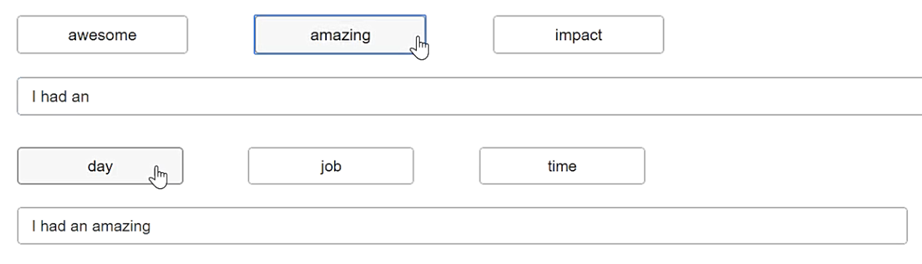